# Supervised Multiblock analyses

Florence Mehl

October 06, 2026

# Context and dataset introduction

This dataset originates from a nutrigenomic study in mice (Martin et al., 2007), designed to investigate how dietary fatty acid composition influences liver lipid profiles and hepatic gene expression.

**Experimental Design**

Forty mice were cross-classified according to two experimental factors, each with multiple levels:

- Genotype (2 levels):  
  Wild-type (WT)  
  PPARα knockout (PPARα -/-)
- Diet (5 levels):

REF: Reference diet (50/50 corn and colza oils)  
COC: Saturated fatty acid-rich diet (hydrogenated coconut oil)  
SUN: Omega-6-rich diet (sunflower oil)  
LIN: Omega-3-rich diet (linseed oil)  
FISH: Mixed diet (corn/colza/enriched fish oils in 43/43/14 ratio)

Each genotype-diet combination includes four biological replicates.

**Variables Collected**

Two sets of variables were measured for each mouse:

- Gene Expression:

Expression levels of 120 selected hepatic genes, chosen from ~30,000 candidates for their relevance to nutritional regulation.  
Measured using nylon macroarrays with radioactive labeling.

- Lipid Composition:

Relative concentrations (percentages) of 21 hepatic fatty acids.  
Quantified via gas chromatography.

```r
data("nutrimouse")
genes <- nutrimouse$gene
lipids <- nutrimouse$lipid
metadata <- data.frame(genotype = nutrimouse$genotype, diet = nutrimouse$diet)
metadata$sample_name <- paste0(rownames(metadata), "_", metadata$genotype, "_", metadata$diet)
rownames(genes) <- metadata$sample_name
rownames(lipids) <- metadata$sample_name
```

# Discriminant analysis of genotypes

## Block PLS-DA Analysis

- Format lipid and gene data as a list of dataframes.
- Define the outcome variable (genotype) as a factor.
- Run block.plsda() from the mixOmics package to model genotype discrimination.

```r
# prepare data
blockPLS_data <- list(genes=genes, lipids=lipids)
genotype <- as.factor(metadata$genotype)

# run analysis
blockPLS_res <- block.plsda(X = blockPLS_data, Y = genotype, design = "full", all.outputs = T, ncomp = 10)
```

## Latent Variable Selection

- Use perf() to evaluate model performance across components and visualise.
- Re-run block.plsda() using the optimal number of latent variables.

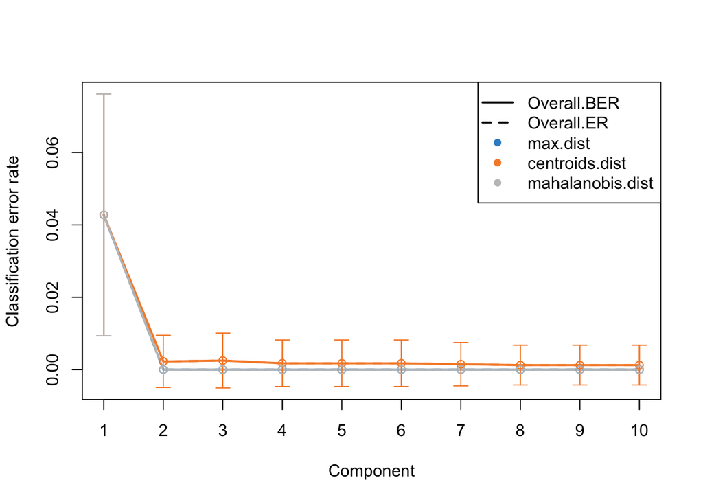

```r
bp <- MulticoreParam(workers = 4)

blockPLS_perf <- perf(blockPLS_res, validation = 'Mfold', folds = 7, nrepeat = 1, auc = TRUE, BPPARAM = bp, progressBar = FALSE)

blockPLS_perf <- perf(
  blockPLS_res,
  validation = "Mfold",
  folds = 7,
  nrepeat = 100,
  auc = TRUE,
  BPPARAM = bp,
  seed = 1
)

plot(blockPLS_perf)
```

```r
blockPLS_res <- block.plsda(X = blockPLS_data, Y = genotype, design = "full", all.outputs = T, ncomp = 2)
```

## Model Significance

- Perform a cross-validation to estimate how well your fitted MBPLSDA/DIABLO model generalises to new data using DIABLO.cv() from the RVAideMemoire package.
- Perform a permutation test to test whether your observed model performance is significantly better than chance using DIABLO.test() from the RVAideMemoire package.

```r
# Cross-validation with DIABLO.cv()
blockPLS_cv <- DIABLO.cv(blockPLS_res,
                         validation = c("Mfold"),
                         k = 7,
                         repet = 100)

blockPLS_cv
```

```
##
##         Cross validation
##
## Model: DIABLO
## 7-fold validation
## Validation repeated 100 times
## 2 components
##
## Classification criterion: Mahalanobis distance
##
## Mean (standard error) classification error rate (%): 0.5 (0.013)
```

```r
# Permutation test with DIABLO.test()
blockPLS_permtest <- DIABLO.test(blockPLS_res,
                                 nperm = 100,
                                 progress = TRUE)
```

[output not shown]

```r
blockPLS_permtest
```

```
##
##  Permutation test based on cross-validation
##
## data:  blockPLS_res
## DIABLO (2 components)
## 100 permutations
## CER = 0, p-value = 0.009901
```

## Explained Variance?

Plot explained variance per block and globally across latent variables. - Percentage of variance explained in each block by each LV: AVE_X - How strongly each block contributes to global LV structure: AVE[[“AVE_outer”]]

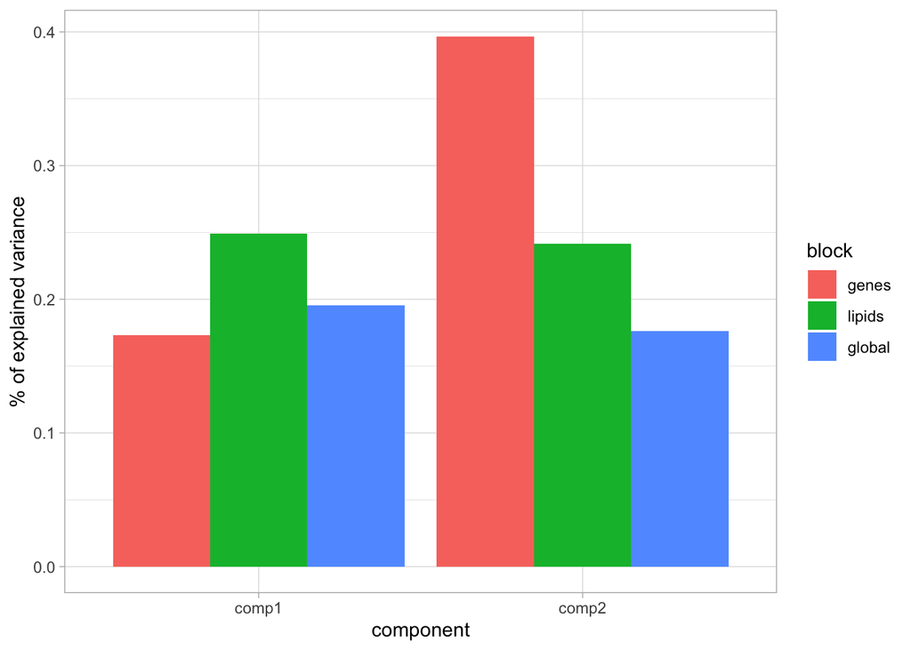

```r
blockPLS_expl <- do.call("rbind",blockPLS_res$AVE$AVE_X[1:2])

# extract the cumulative global explained variance
ave_outer_cum <- blockPLS_res$AVE[["AVE_outer"]]
# convert to incremental (per component)
ave_outer_inc <- data.frame(comp1 = ave_outer_cum[1], comp2= diff(ave_outer_cum), row.names = "global")

blockPLS_expl <- rbind(blockPLS_expl, ave_outer_inc)
blockPLS_expl$block <- rownames(blockPLS_expl)
blockPLS_expl <- melt(blockPLS_expl)
blockPLS_expl$block <- factor(blockPLS_expl$block, levels = c("genes", "lipids", "global"))

ggplot(blockPLS_expl, aes(x=variable, y=value, fill=block)) +
  geom_bar(stat="identity", position=position_dodge()) +
  labs(x="component",
       y="% of explained variance") +
  theme_light()
```

## Sample Space Visualization

- Use plotIndiv() to visualize sample distributions in latent variable space.

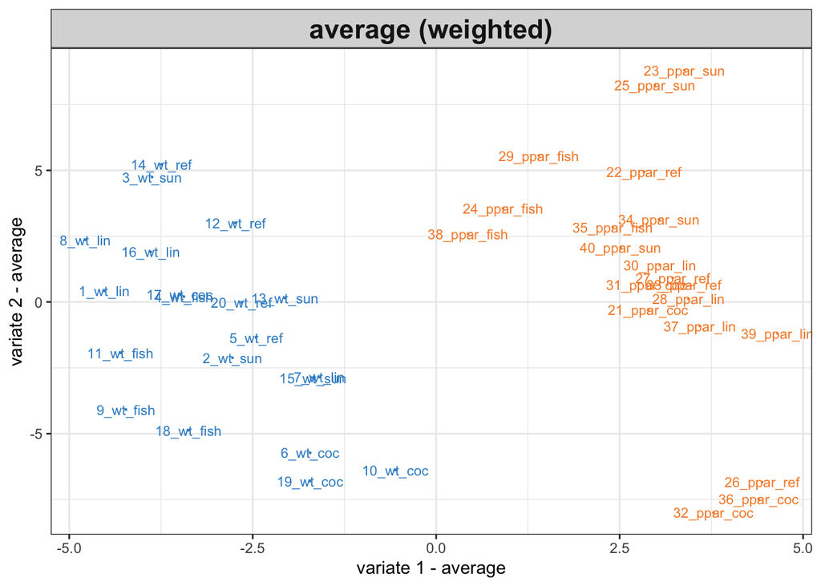

```r
plotIndiv(blockPLS_res, block = "weighted.average")
```

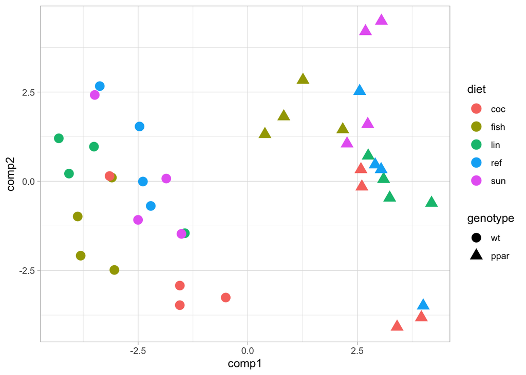

```r
# ou:

blockPLS_variates.weighted <- blockPLS_res$variates[c("genes", "lipids")]
for(omic in c("genes", "lipids")){
  for(comp in c("comp1", "comp2")){
      blockPLS_variates.weighted[[omic]][,comp] <- blockPLS_variates.weighted[[omic]][,comp] * blockPLS_res$weights[omic, comp]
  }
}
blockPLS_scores.weighted <- abind(blockPLS_variates.weighted[c("genes", "lipids")], along = 3)
blockPLS_scores.weighted <- apply(blockPLS_scores.weighted, c(1,2), mean)

blockPLS_scores.weighted <- data.frame(metadata, blockPLS_scores.weighted)

ggplot(blockPLS_scores.weighted, aes(x=comp1, y=comp2, col=diet, shape = genotype)) +
  geom_point(size=4) +
  theme_light()
```

## Variable Contributions

- Use plotVar() to identify discriminant genes and lipids contributing to genotype separation.

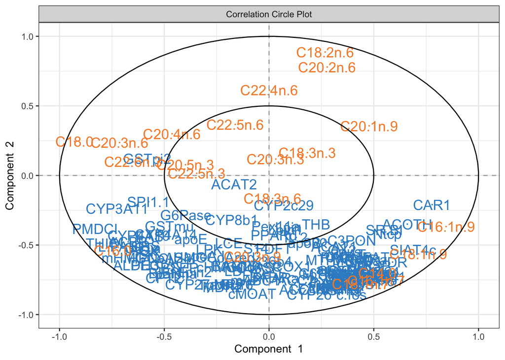

```r
plotVar(blockPLS_res)
```

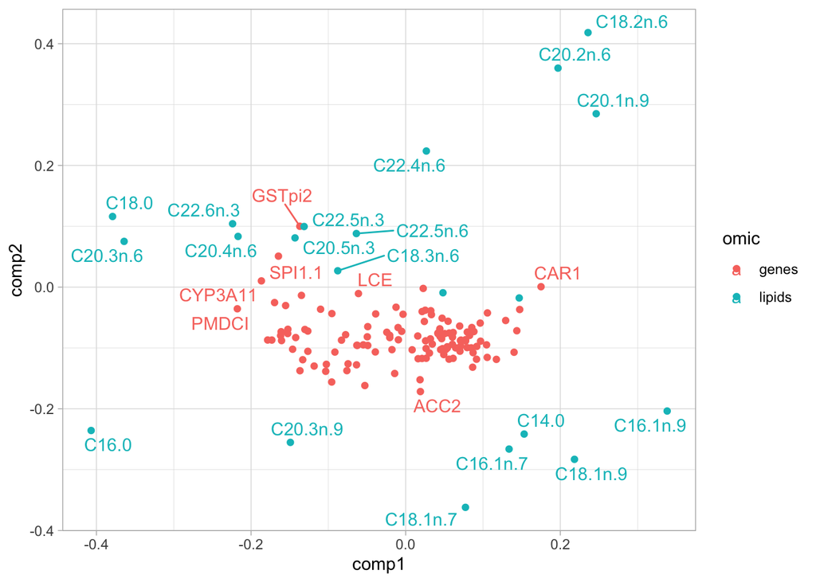

```r
# ou

blockPLS_loadings_genes <- blockPLS_res$loadings$genes
blockPLS_loadings_lipids <- blockPLS_res$loadings$lipids
blockPLS_loadings <- rbind.data.frame(blockPLS_loadings_genes, blockPLS_loadings_lipids)
blockPLS_loadings$omic <- c(rep("genes", dim(genes)[[2]]), rep("lipids", dim(lipids)[[2]]))
blockPLS_loadings$variable <- rownames(blockPLS_loadings)

ggplot(blockPLS_loadings, aes(x=comp1, y=comp2, col=omic, label=variable)) +
  geom_point() +
  geom_text_repel() +
  theme_light()
```

# Consensus OPLS Discriminant Analysis of genotypes

## Data Preparation

- Organize lipid and gene datasets as a list of dataframes (one per block).
- Encode the outcome variable (genotype).

```r
COPLS_data <- list(genes=as.matrix(genes), lipids=as.matrix(lipids))
COPLS_data <- lapply(COPLS_data, scale)
genotype <- metadata$genotype
dummy_genotype <- as.matrix(data.frame(wt = ifelse(genotype == "wt", 1, 0),ppar = ifelse(genotype == "ppar", 1, 0)))
```

## Consensus OPLS Analysis

- Fit the Consensus OPLS model using ConsensusOPLS() from the ConsensusOPLS package.
- Model the relationship between the predictor blocks (lipids, genes) and the genotype outcome.

```r
COPLS_res <- ConsensusOPLS(
  data = COPLS_data,
  Y = genotype,
  maxPcomp = 1,
  maxOcomp = 1,
  modelType = "da",
  cvType = "nfold",
  nfold = 5,
  nperm = 100,
  verbose = T,
  kernelParams = list(type='p', params = c(order=1.0))
)
```

## Model significance

- Assess statistical significance using permutation tests and visualize with histograms of Q², dQ², and R²Y values from permuted models.
- The results of permutations can be found in `COPLS_res$permStats`.
- The results for the optimal model can be found in `COPLS_res$optimal$modelCV` and `COPLS_res$optimal$modelCV$cv`
- plot Q2 permutations
- plot DQ2 permutations
- plot R2Y permutations

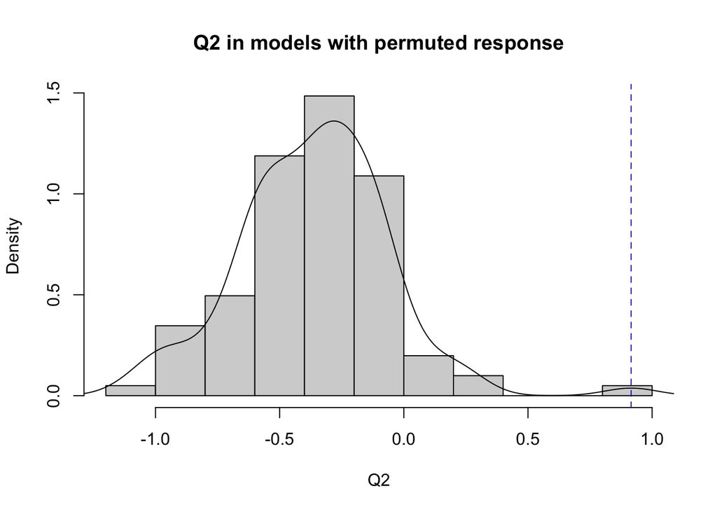

```r
plotQ2(COPLS_res)
```

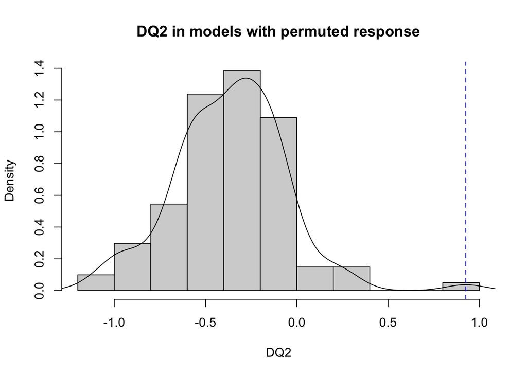

```r
plotDQ2(COPLS_res)
```

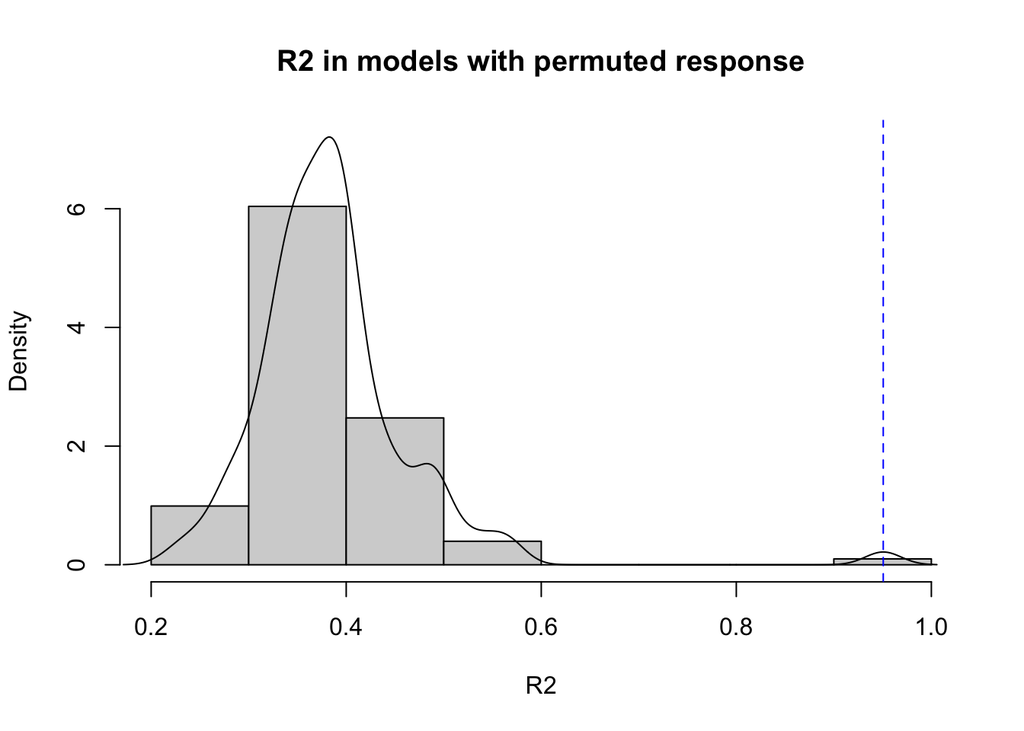

```r
plotR2(COPLS_res)
```

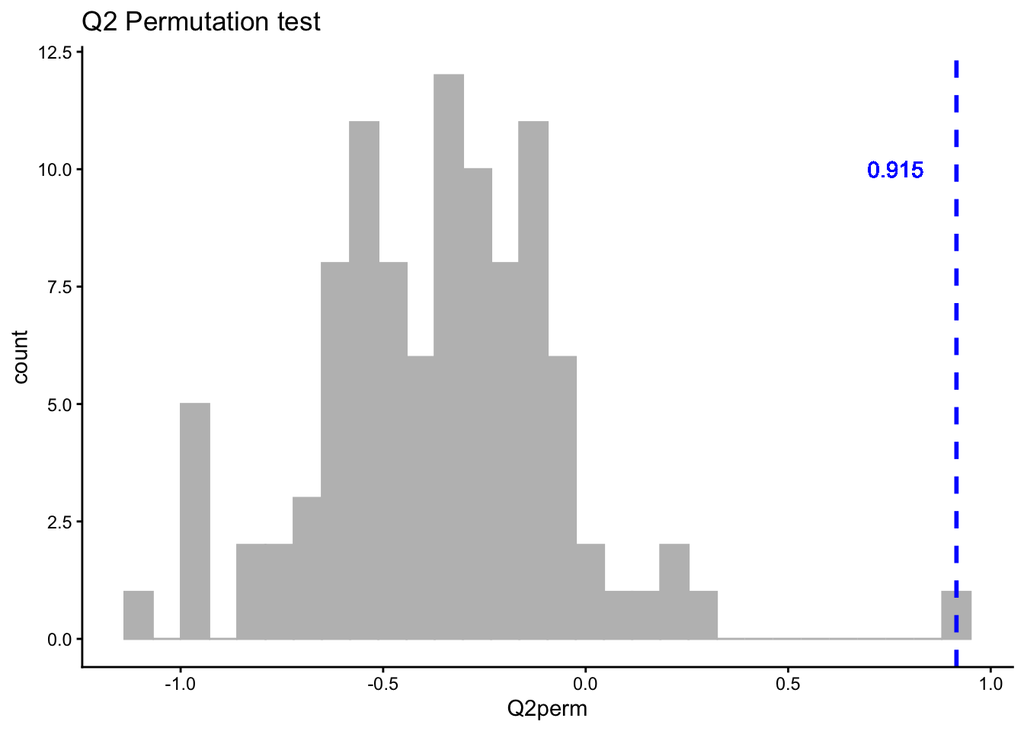

```r
#or

Q2perm <- data.frame(Q2perm = COPLS_res@permStats$Q2Y)

ggplot(data = Q2perm, aes(x = Q2perm)) +
  geom_histogram(color="grey", fill="grey") +
  geom_vline(aes(xintercept=COPLS_res@Q2["po1"]),color="blue", linetype="dashed", size=1) +
  geom_text(x=COPLS_res@Q2["po1"]-0.15, y=10, label=round(COPLS_res@Q2["po1"],3), col="blue") +
  theme_classic() +
  ggtitle("Q2 Permutation test")
```

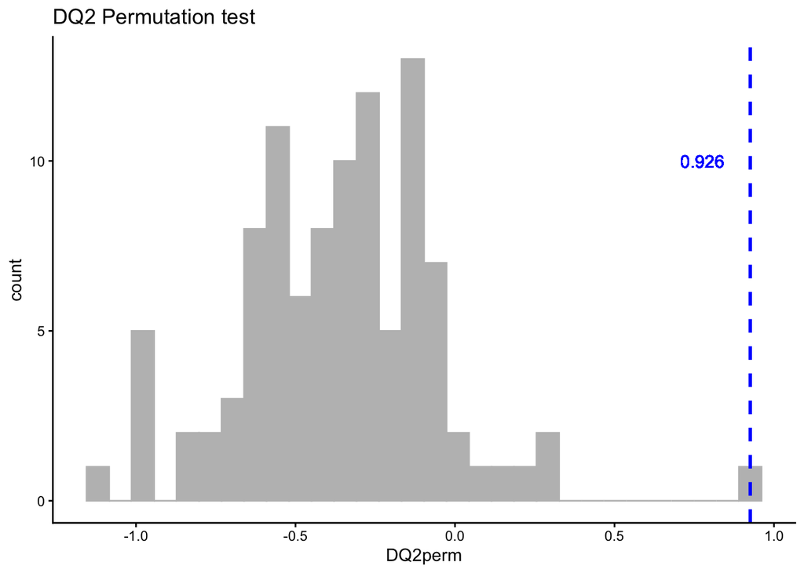

```r
DQ2perm <- data.frame(DQ2perm = COPLS_res@permStats$DQ2Y)

ggplot(data = DQ2perm, aes(x = DQ2perm)) +
  geom_histogram(color="grey", fill="grey") +
  geom_vline(aes(xintercept=COPLS_res@DQ2["po1"]),color="blue", linetype="dashed", size=1) +
  geom_text(x=COPLS_res@DQ2["po1"]-0.15, y=10, label=round(COPLS_res@DQ2["po1"],3), col="blue") +
  theme_classic() +
  ggtitle("DQ2 Permutation test")
```

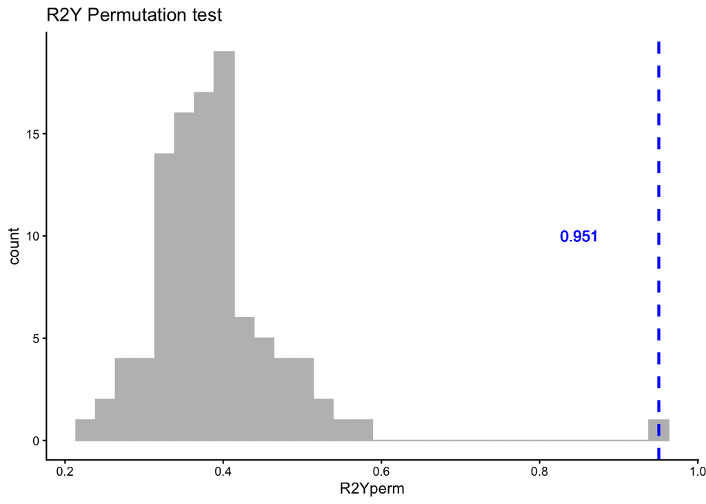

```r
R2Yperm <- data.frame(R2Yperm = COPLS_res@permStats$R2Y)

ggplot(data = R2Yperm, aes(x = R2Yperm)) +
  geom_histogram(color="grey", fill="grey") +
  geom_vline(aes(xintercept=COPLS_res@R2Y["po1"]),color="blue", linetype="dashed", size=1) +
  geom_text(x=COPLS_res@R2Y["po1"]-0.1, y=10, label=round(COPLS_res@R2Y["po1"],3), col="blue") +
  theme_classic() +
  ggtitle("R2Y Permutation test")
```

## Block Contributions

-Plot block contributions as a bar plot to see which omics layer drives genotype discrimination.

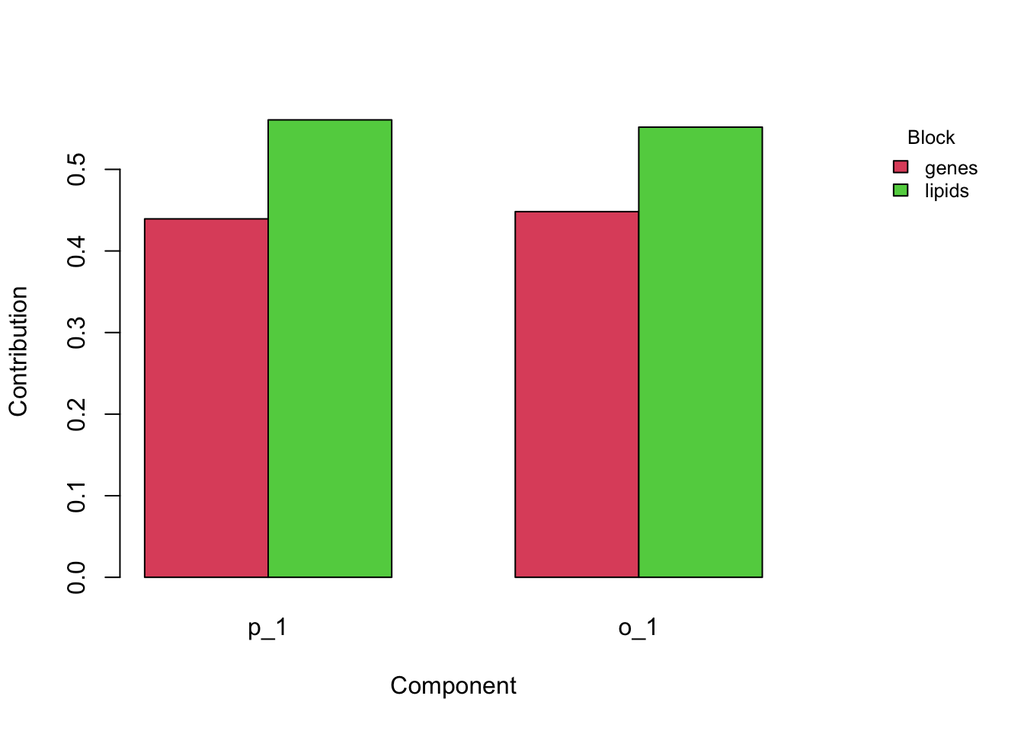

```r
plotContribution(COPLS_res)
```

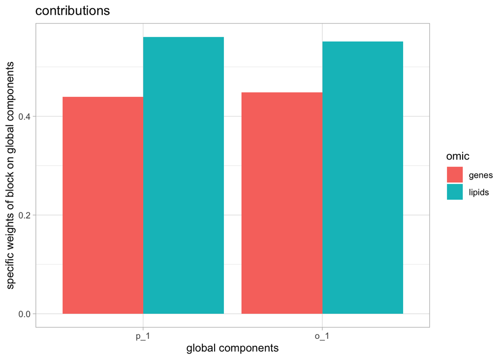

```r
# or

contributions <- COPLS_res@blockContribution
contributions <- melt(contributions)
colnames(contributions) <- c("dataset", "Dim", "value")

ggplot(contributions, aes(x=Dim, y=value, fill=dataset)) +
  geom_bar(stat = "identity", position=position_dodge()) +
  theme_light() +
  labs(x = "global components", y = "specific weights of block on global components", fill = "omic",
       title = "contributions")
```

## Sample Space Visualization

- Plot scores to visualize sample distribution in the space of predictive and orthogonal latent variables.

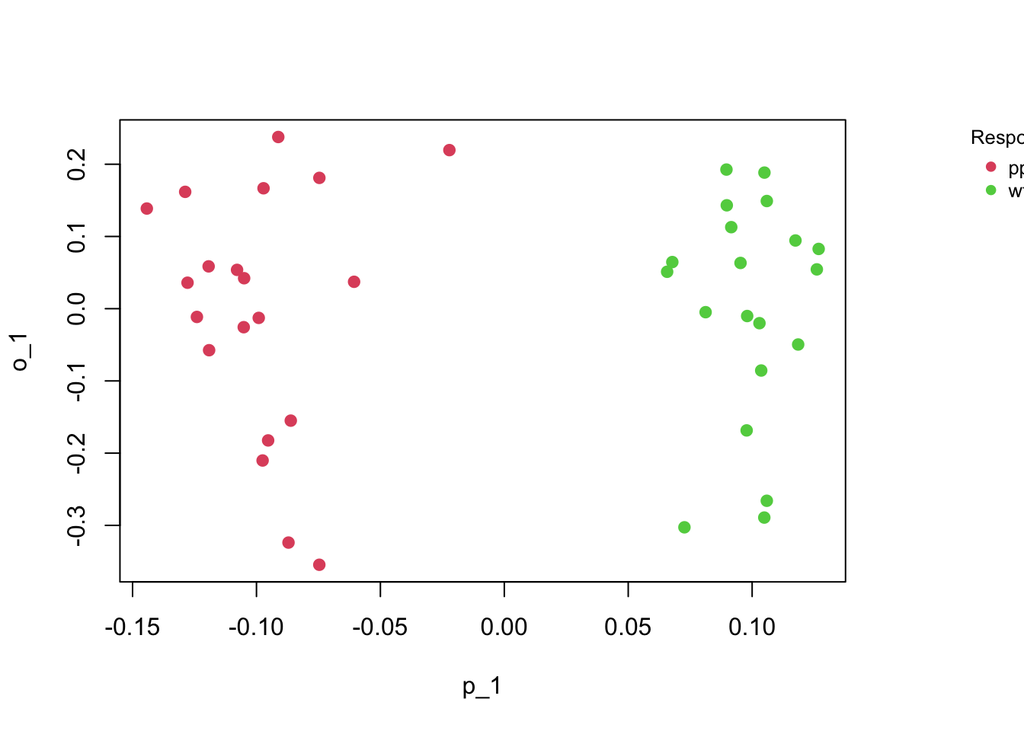

```r
plotScores(COPLS_res)
```

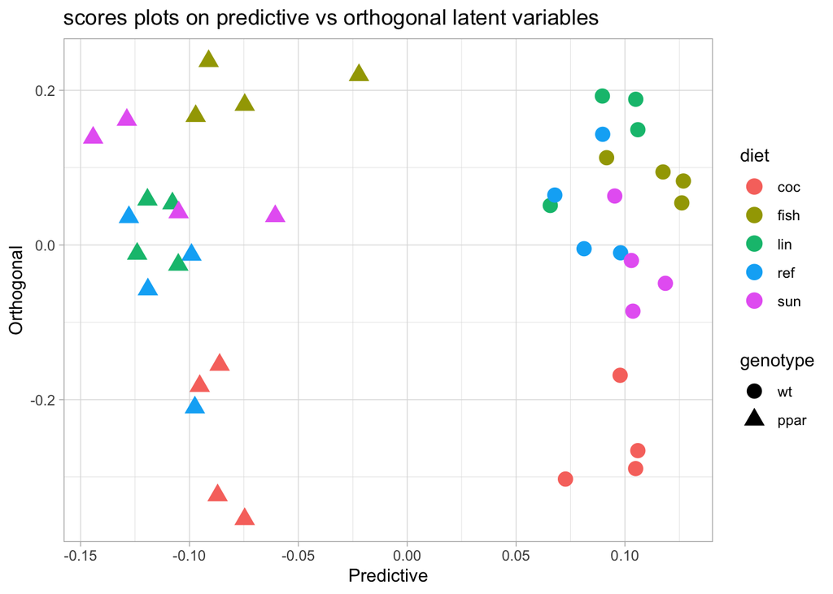

```r
# or

scores <- data.frame(metadata, COPLS_res@scores)

ggplot(scores, aes(x=p_1, y=o_1, col=diet, shape = genotype)) +
  geom_point(size=4) +
  labs(x="Predictive",
       y="Orthogonal",
       title = "scores plots on predictive vs orthogonal latent variables") +
  theme_light()
```

## Variable Contributions

- Plot loadings: predictive vs orthogonal components
- Interpret biological relevance

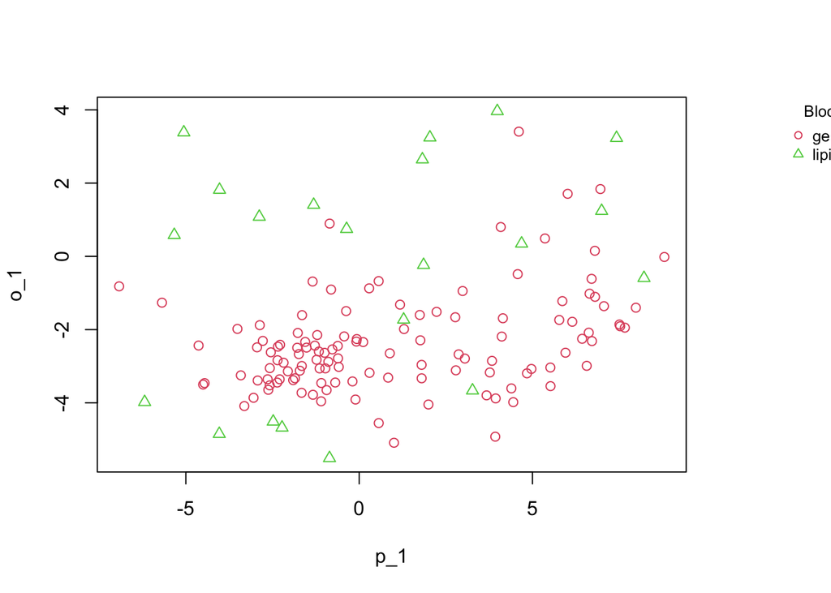

```r
plotLoadings(COPLS_res)
```

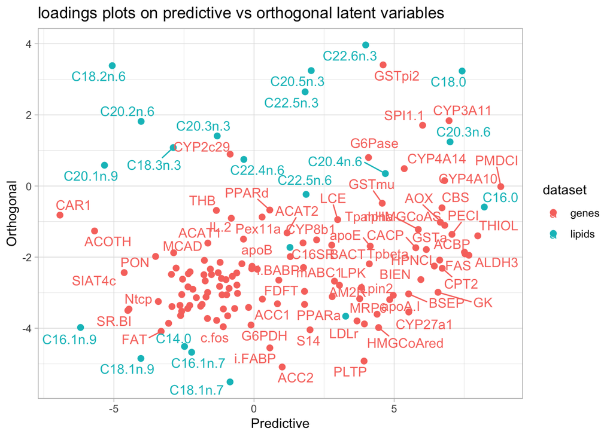

```r
# or

loadings <- rbind.data.frame(COPLS_res@loadings$genes, COPLS_res@loadings$lipids)
loadings$dataset <- c(rep("genes", nrow(COPLS_res@loadings$genes)), rep("lipids", nrow(COPLS_res@loadings$lipids)))
loadings$variable <- rownames(loadings)

ggplot(loadings, aes(x=p_1, y=o_1, col=dataset, label = variable)) +
  geom_point(size=2) +
  labs(x="Predictive",
       y="Orthogonal",
       title = "loadings plots on predictive vs orthogonal latent variables") +
  geom_text_repel() +
  theme_light()
```

- Identify most discriminant genes plotting VIP vs loadings on predictive component

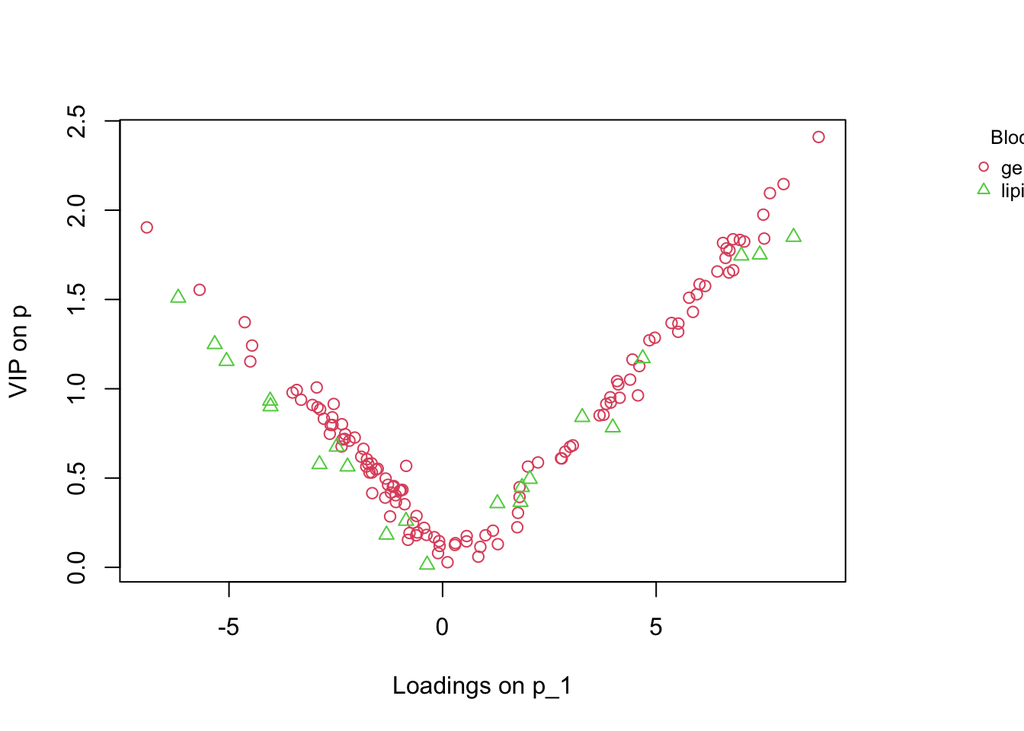

```r
plotVIP(COPLS_res)
```

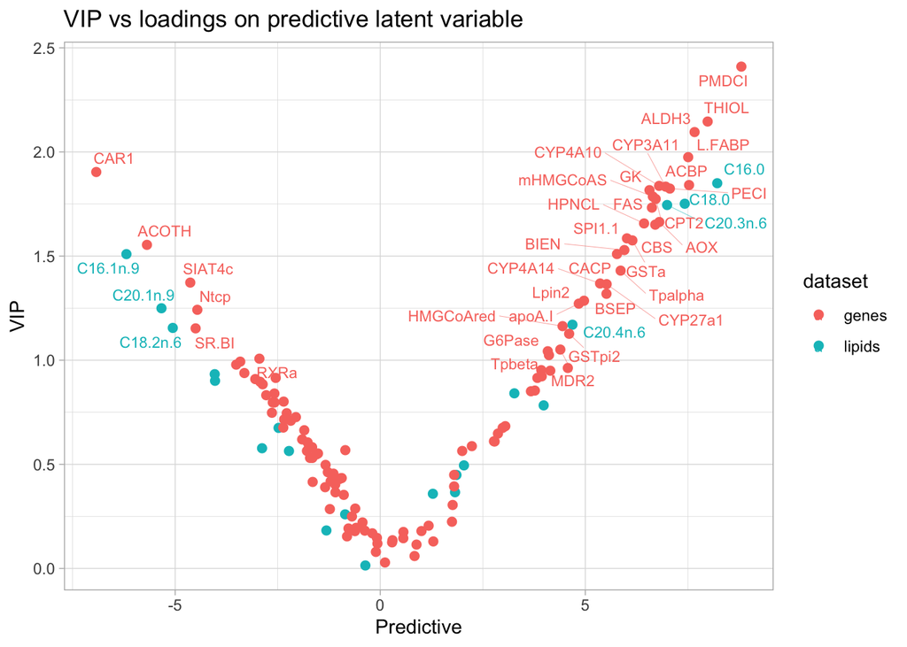

```r
# or

VIP <- data.frame(VIP = c(COPLS_res@VIP$genes$p, COPLS_res@VIP$lipids$p), variable = c(rownames(COPLS_res@VIP$genes), rownames(COPLS_res@VIP$lipids)))

loadings_VIP <- merge(loadings, VIP, by="variable")
loadings_VIP$label <- ifelse(loadings_VIP$VIP > 1, loadings_VIP$variable, NA)

ggplot(loadings_VIP, aes(x=p_1, y=VIP, col=dataset, label = label)) +
  geom_point(size=2) +
  labs(x="Predictive",
       y="VIP",
       title = "VIP vs loadings on predictive latent variable") +
  geom_text_repel(size=3, max.overlaps = 50, segment.size=.1) +
  theme_light()
```

## Predicting with consensusOPLS

Train a Consensus OPLS-DA model to discriminate between WT and PPAR samples using a training set and evaluate its performance on an independent test set.

### Data Splitting

- Select 30 samples for training and 10 samples for testing.
- Organize lipid and gene datasets as lists of matrices for training and testing.
- Scale each block separately for training and test sets.
- Define the outcome variable (genotype) for the training set.

```r
test.observations <-c(sample(1:20, 5, replace = F),
                      sample(21:40, 5, replace = F))
train.data <- list(genes=as.matrix(genes[-test.observations,]),
                   lipids=as.matrix(lipids[-test.observations,]))
train.data <- lapply(train.data, scale)
test.data <- list(genes=as.matrix(genes[test.observations,]),
                  lipids=as.matrix(lipids[test.observations,]))
test.data <- lapply(test.data, scale)

train.genotype <- metadata$genotype[-test.observations]
```

### Consensus OPLS Analysis

- Fit the Consensus OPLS model on the training set.

```r
train.COPLS_res <- ConsensusOPLS(
  data = train.data,
  Y = train.genotype,
  maxPcomp = 1,
  maxOcomp = 1,
  modelType = "da",
  cvType = "nfold",
  nfold = 5,
  nperm = 100,
  verbose = T,
  kernelParams = list(type='p', params = c(order=1.0))
)
```

### Model Evaluation

- Assess statistical significance using permutation tests.
- visualize plotting Q², dQ², and R²Y values from permuted models.
- Observe block contributions, scores and loadings.

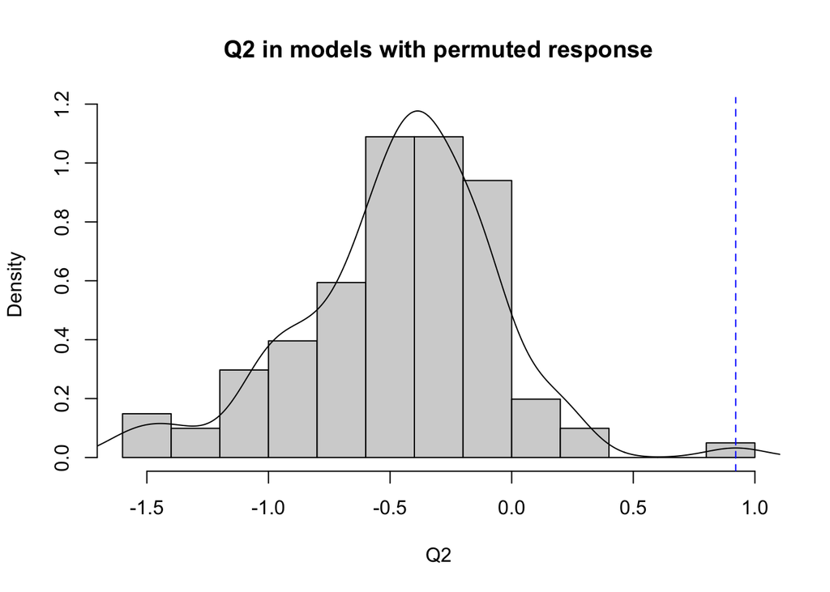

```r
plotQ2(train.COPLS_res)
```

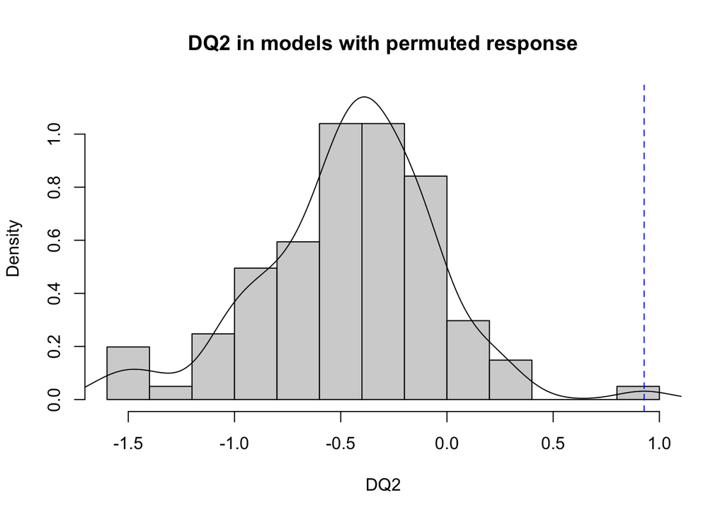

```r
plotDQ2(train.COPLS_res)
```

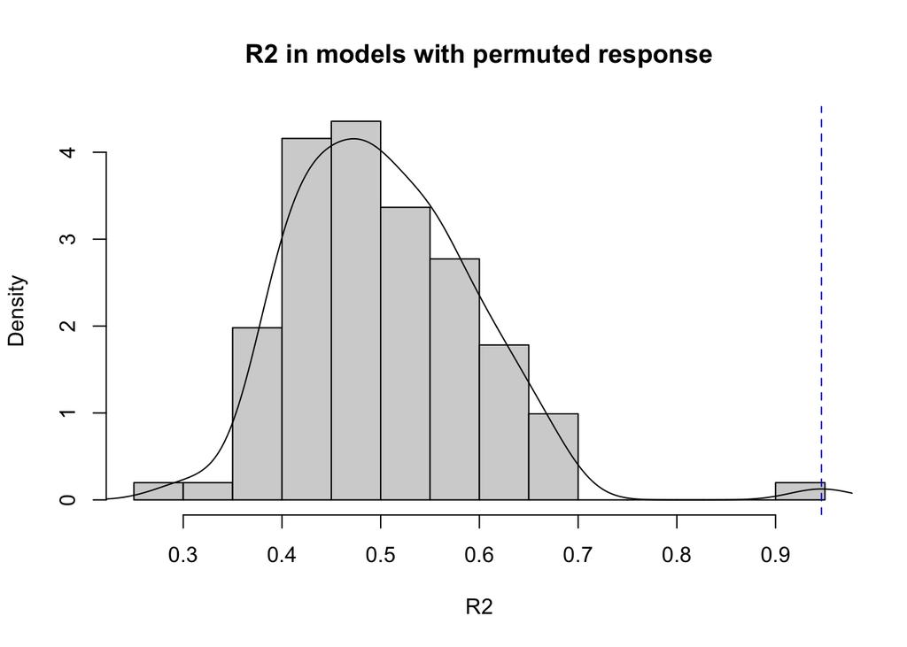

```r
plotR2(train.COPLS_res)
```

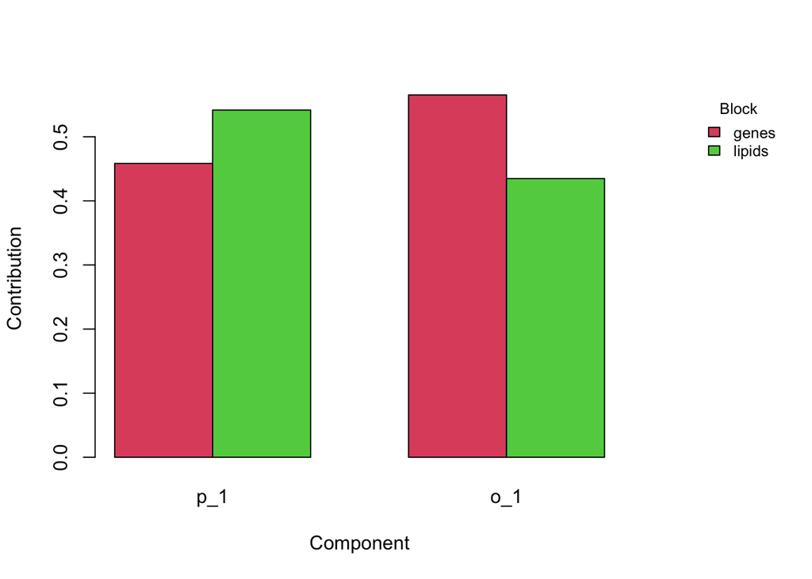

```r
plotContribution(train.COPLS_res)
```

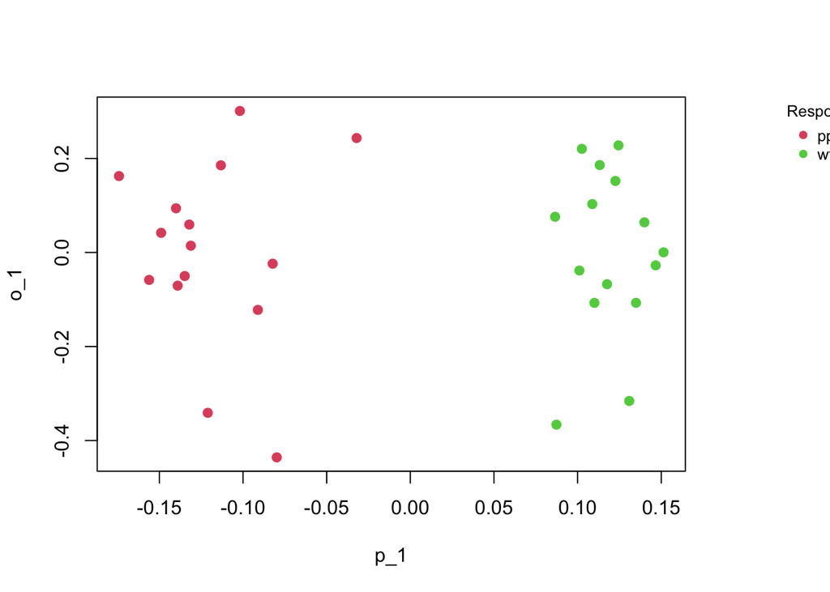

```r
plotScores(train.COPLS_res)
```

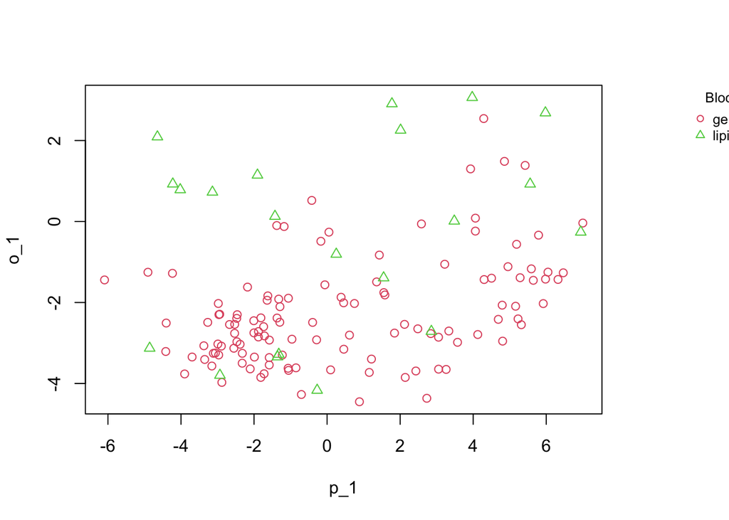

```r
ConsensusOPLS::plotLoadings(train.COPLS_res) #because mixOmics also has a function called plotLoadings()
```

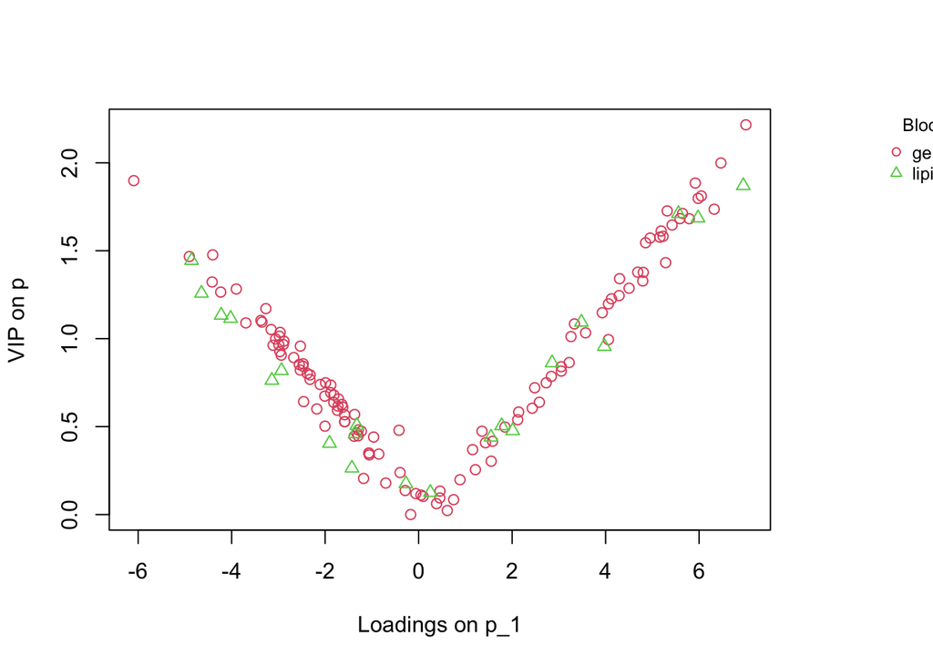

```r
plotVIP(train.COPLS_res)
```

### External Validation on Test Set

- Predict class labels for the independent test samples using predict().
- Compare predicted classes and predicted Y values against the true genotypes.
- Summarize in a table for accuracy evaluation.

```r
test.COPLS_res <- predict(object = train.COPLS_res,
                          newdata = test.data)


data.frame(test.COPLS_res$class,
           Y.pred = test.COPLS_res$Y,
           True.genotype=metadata$genotype[test.observations])
```

```
##              class    margin softmax.ppar   softmax.wt Y.pred.ppar    Y.pred.wt
## 19_wt_coc       wt 1.9121259  0.000000000 1.000000e+00  -0.4560630  1.456062965
## 2_wt_sun        wt 1.6418375  0.000000000 1.000000e+00  -0.3209187  1.320918734
## 7_wt_lin        wt 0.7479927  0.002478417 9.975216e-01   0.1260036  0.873996363
## 3_wt_sun        wt 1.4574871  0.000000000 1.000000e+00  -0.2287435  1.228743543
## 15_wt_sun       wt 1.4167981  0.000000000 1.000000e+00  -0.2083990  1.208399040
## 23_ppar_sun   ppar 2.0598876  1.000000000 0.000000e+00   1.5299438 -0.529943821
## 21_ppar_coc   ppar 1.2083662  1.000000000 0.000000e+00   1.1041831 -0.104183080
## 24_ppar_fish  ppar 0.9911932  1.000000000 1.738585e-98   0.9955966  0.004403384
## 36_ppar_coc   ppar 1.3183638  1.000000000 0.000000e+00   1.1591819 -0.159181903
## 27_ppar_ref   ppar 1.5984305  1.000000000 0.000000e+00   1.2992152 -0.299215226
##              True.genotype
## 19_wt_coc               wt
## 2_wt_sun                wt
## 7_wt_lin                wt
## 3_wt_sun                wt
## 15_wt_sun               wt
## 23_ppar_sun           ppar
## 21_ppar_coc           ppar
## 24_ppar_fish          ppar
## 36_ppar_coc           ppar
## 27_ppar_ref           ppar
```